# IODS course diary

Hans Hellén

# About the project

**This is a very famous course called [Introduction to Open Data Science](https://courses.helsinki.fi/fi/HYMY005/120776718) organised at University of Helsinki in autumn 2017.** My personal repository is [here](https://github.com/daphnia/IODS-project).

I am working with R version 3.2.5 (2016-04-14) (nickname Very, Very Secure Dishes) and currently I have RStudio version 1.0.136. I found it helpful to adjust the GUI size a bit larger and change the theme to *Merbivore*: Go to *Tools* > *Global Options* > *Appearance*, and adjust there *Zoom* and *Editor theme*. The R Markdown theme called *journal* is used in this course diary. Command `?html_dependency_bootstrap()` to find the list of themes. The font size had to be adjusted bigger by adding this lines to index.Rmd:

`<style type="text/css">`

`body{ /* Normal */`  
`font-size: 20px;`  
`}`

`</style>`

# RStudio Exercise 2: Regression and Model Validation

## Data Wrangling and General Remarks

First I did some data wrangling, i.e. formatting a dataset to be suitable and nice to be used in an analysis later, in this case in regression analysis. The data wrangling was done in a R Script file *create_learning2014.R* and the formatted dataset is in a file *learning2014.csv*. As described in the wrangling file the data was originally collected for international survey of Approaches to Learning. For details and links to further information have a look at the create_learning2014.R at my [repository](https://github.com/daphnia/IODS-project).

After practising and doing a bit of the exercise the RStudio workspace became a bit cluttered. So, I found that a function `remove(...)` can be used to remove objects from the memory. It is handy to clean up the environment once in a while.

Another important thing is that you have to load the extra libraries every time you start RStudio, even though files create_learning2014.R, .RData and .Rhistory are used to load the situation where you were when quitting last time.

## Analysis

Let’s first read the data set into memory and have a look at the data set. Summary off the variables are below:

```r
#getwd()
#NOTE: some functions are commented out to make the knitted output more simple.
learning2014 <- read.csv("data/learning2014.csv", header = TRUE)
str(learning2014)
```

```
## 'data.frame':    166 obs. of  7 variables:
##  $ gender  : Factor w/ 2 levels "F","M": 1 2 1 2 2 1 2 1 2 1 ...
##  $ age     : int  53 55 49 53 49 38 50 37 37 42 ...
##  $ attitude: int  37 31 25 35 37 38 35 29 38 21 ...
##  $ deep    : num  3.58 2.92 3.5 3.5 3.67 ...
##  $ stra    : num  3.38 2.75 3.62 3.12 3.62 ...
##  $ surf    : num  2.58 3.17 2.25 2.25 2.83 ...
##  $ points  : int  25 12 24 10 22 21 21 31 24 26 ...
```

```r
summary(learning2014)
```

```
##  gender       age           attitude          deep            stra
##  F:110   Min.   :17.00   Min.   :14.00   Min.   :1.583   Min.   :1.250
##  M: 56   1st Qu.:21.00   1st Qu.:26.00   1st Qu.:3.333   1st Qu.:2.625
##          Median :22.00   Median :32.00   Median :3.667   Median :3.188
##          Mean   :25.51   Mean   :31.43   Mean   :3.680   Mean   :3.121
##          3rd Qu.:27.00   3rd Qu.:37.00   3rd Qu.:4.083   3rd Qu.:3.625
##          Max.   :55.00   Max.   :50.00   Max.   :4.917   Max.   :5.000
##       surf           points
##  Min.   :1.583   Min.   : 7.00
##  1st Qu.:2.417   1st Qu.:19.00
##  Median :2.833   Median :23.00
##  Mean   :2.787   Mean   :22.72
##  3rd Qu.:3.167   3rd Qu.:27.75
##  Max.   :4.333   Max.   :33.00
```

It consists of 166 observations of 7 variables. The variables deep (deep learning), stra (strategic learning) and surf (surface learning) represents three different dimensions of the way of learning. They have been calculated as means of several other variables in the previous data wrangling. This data is in Likert scale and based on data originally obtained from a questionnaire.

There is a noticeable deviation (*skewness*) in age at the highest quartile, shifting the mean age away from median value towards the older end of the distribution. This can be seen clearly from a histogram below:

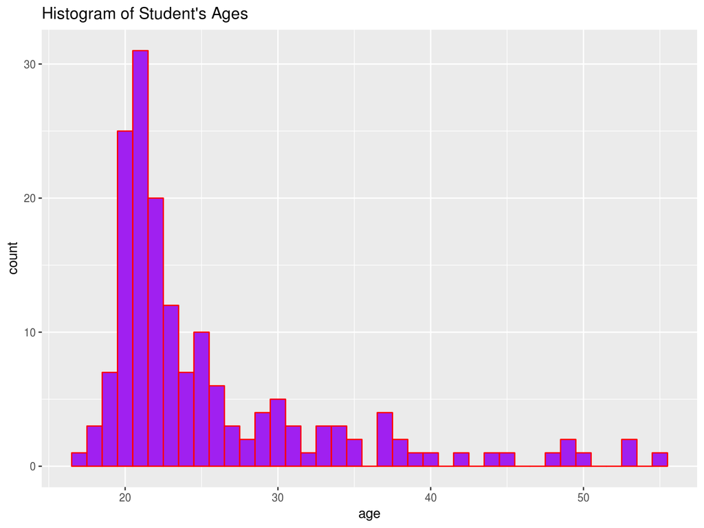

```r
library(ggplot2)
p_age <- ggplot(learning2014, aes(age)) + geom_histogram(binwidth = 1, fill="purple", colour="red") + ggtitle("Histogram of Student's Ages")
p_age
```

Scatter plots of all the variables using gender as a factor are presented in a matrix below. This is just to show, how much better plots can be produced by GGally and ggplot2 libraries. Those are found below this first picture:

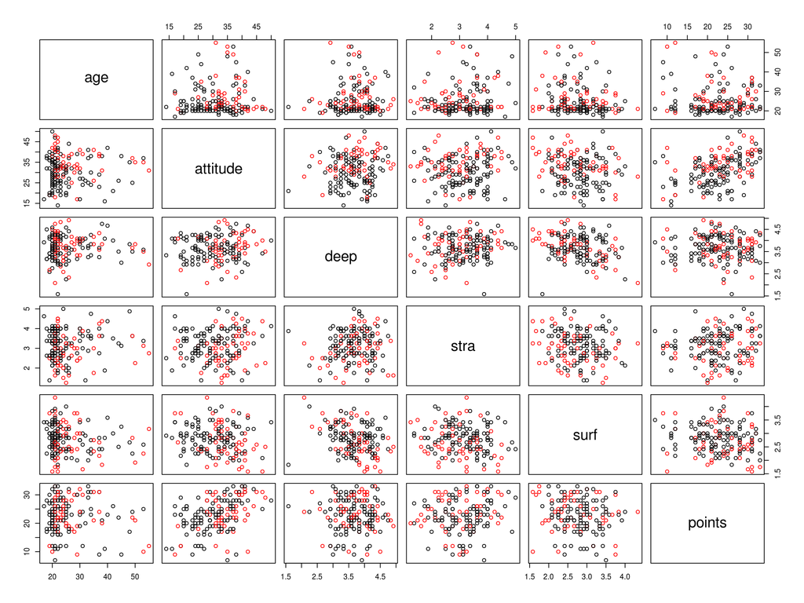

**In this scatter plot matrix black dots marks females and red dots marks males**

```r
pairs(learning2014[-1], col=learning2014$gender)
```

GGally and ggplot2 produces another, more informative, scatterplot matrix:

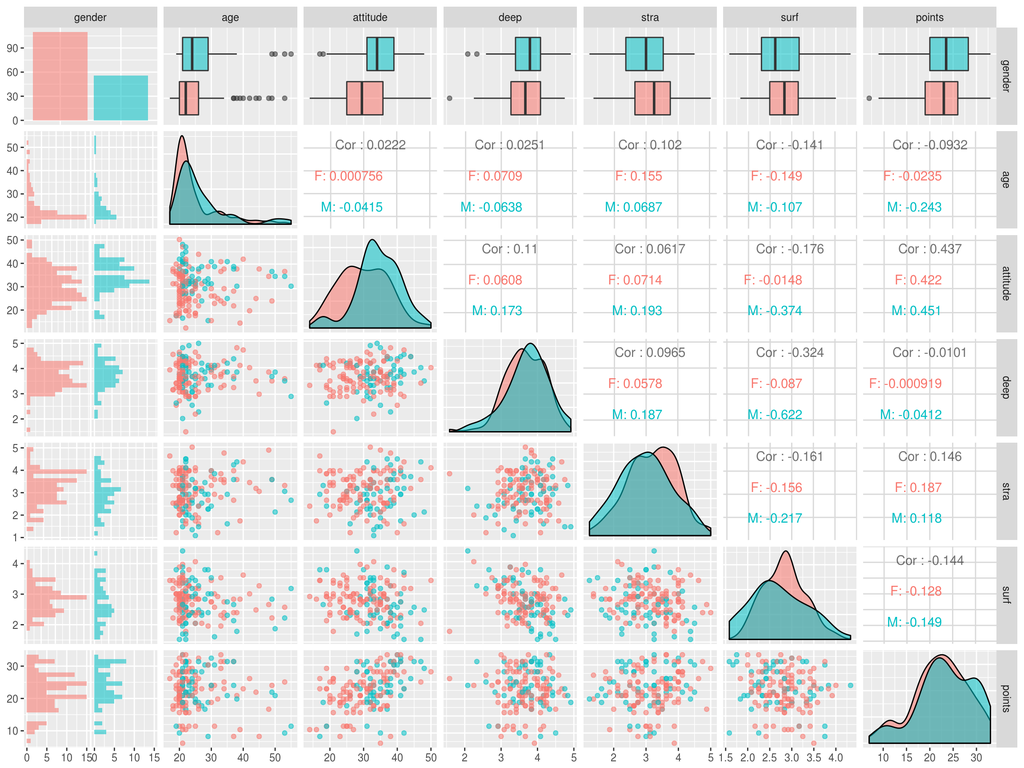

**In this scatter plot matrix red color marks females and blue color marks males**

```r
library(ggplot2)
library(GGally)
p <- ggpairs(learning2014, mapping = aes(col = gender, alpha = 0.3), lower = list(combo = wrap("facethist", bins = 20)))
p
```

- It can be seen from the matrix above that there are remarkably more females than males.
- It could be analysed if there is statistically significant correlation between gender and attitude (note: there is a tail or a tiny peak of males with low attitude).
- Gender probably does not explain statistically if one has obtained surface learning as a strategy, although the distributions look a bit different between genders because of *kurtosis*. It means that only the variances are different between genders when means are about the same. The variability is higher among males.
- Also correlation between attitude vs. exam points should be checked. Alternative hypothesis could be: higher attitude results in higher points.
- There could be a statistically significant negative correlation between deep and surf, which is quite obvious according to common sense. In correlation coefficients there is also some difference between genders, which probably is explained by a single female outlier. **According to literature, the correlation coefficient is very sensitive for outliers**, i.e.. abnormal/unexpected values.
- Interesting is if there is not statistically significant correlation between deep learning and exam points, especially among females (note, there might be a female outlier which could explain the low correlation coefficient). This relationship needs more research.
- I cannot see any non-linear relationships. **NOTE:** it is always important to look both the scatter plot and correlation coefficient as even though the correlation coefficient is low there might be **non-linear correlation** seen from scatter plot. Also the low correlation coefficient can be a result of the **sensitivity for outliers**.

### Linear regression model

For the following regression analysis the exam *points* will be a target (aka dependent, response) variable and let’s choose three independent (aka explanatory) variables:

1. *attitude* towards data science
2. use of *deep* learning strategies
3. use of *surf*ace learning strategies.

Here is a regression model with multiple explanatory variables:

```r
my_model <- lm(points ~ attitude + surf + deep, data = learning2014)
summary(my_model)
```

```
##
## Call:
## lm(formula = points ~ attitude + surf + deep, data = learning2014)
##
## Residuals:
##      Min       1Q   Median       3Q      Max
## -16.9168  -3.1487   0.3667   3.8326  11.3519
##
## Coefficients:
##             Estimate Std. Error t value Pr(>|t|)
## (Intercept) 18.35507    4.71237   3.895 0.000143 ***
## attitude     0.34661    0.05766   6.011 1.18e-08 ***
## surf        -1.09114    0.83599  -1.305 0.193669
## deep        -0.94846    0.79025  -1.200 0.231815
## ---
## Signif. codes:  0 '***' 0.001 '**' 0.01 '*' 0.05 '.' 0.1 ' ' 1
##
## Residual standard error: 5.313 on 162 degrees of freedom
## Multiple R-squared:  0.2024, Adjusted R-squared:  0.1876
## F-statistic:  13.7 on 3 and 162 DF,  p-value: 5.217e-08
```

From the summary above it can be seen that only attitude has statistically significant relationship with exam points (p=1.18e-08 so the risk that this is a wrong conclusion, is extremely low). Standard error (0.05766) of regression coefficient for attitude is not an order of magnitude less than the coefficient itself (0.34661), indicating that there is some variability in the estimate for the coefficient. R-squared is about 20 %. It means that on the average only 20 % of variability in predicted exam points can be explained by these three variables. The F-statistic indicates, would the model be better with fewer variables. In that case the p-value would be higher. Now p-value is 5.217e-08. Removing *surf* from the model gives a bit lower p-value 2.326e-08. Removing also the *deep* gives even lower p-value 4.119e-09.

After testing also the other variables and checking the p-values from F-tests, it can be concluded that the best model has only the attitude as an explanatory variable. According to this model below, a student has to rise attitude by three numbers in order to increase exam points by one number. Also the intercept suggests that even if a student has zero attitude, the exam points would be 12 (from the simplified model below), which is quite reasonable.

```r
my_best_model <- lm(points ~ attitude, data = learning2014)
summary(my_best_model)
```

```
##
## Call:
## lm(formula = points ~ attitude, data = learning2014)
##
## Residuals:
##      Min       1Q   Median       3Q      Max
## -16.9763  -3.2119   0.4339   4.1534  10.6645
##
## Coefficients:
##             Estimate Std. Error t value Pr(>|t|)
## (Intercept) 11.63715    1.83035   6.358 1.95e-09 ***
## attitude     0.35255    0.05674   6.214 4.12e-09 ***
## ---
## Signif. codes:  0 '***' 0.001 '**' 0.01 '*' 0.05 '.' 0.1 ' ' 1
##
## Residual standard error: 5.32 on 164 degrees of freedom
## Multiple R-squared:  0.1906, Adjusted R-squared:  0.1856
## F-statistic: 38.61 on 1 and 164 DF,  p-value: 4.119e-09
```

### Model validation

Let’s make some graphical model validation using the following plots: Residuals vs Fitted values, Normal QQ-plot and Residuals vs Leverage.

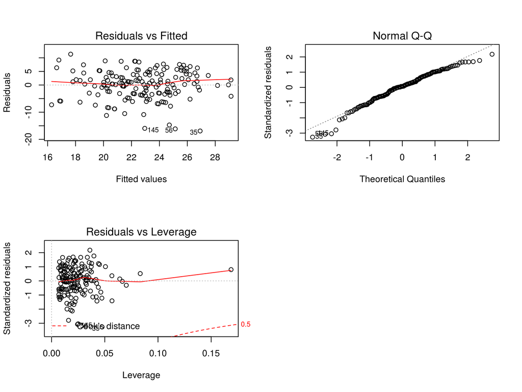

**A model *my_model* explaining exam points with attitude towards data science, use of deep learning strategies and use of surface learning strategies**

```r
par(mfrow = c(2,2))
plot(my_model, which = c(1,2,5))
```

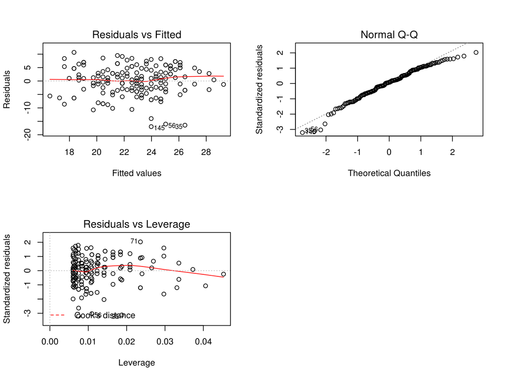

**A model *my_best_model* explaining exam points with attitude towards data science**

```r
par(mfrow = c(2,2))
plot(my_best_model, which = c(1,2,5))
```

As the model is linear regression it is assumed that the relationship between attitude and exam points are linear. From the scatter plots further above it can be seen that this is not exactly the case: there are some observations where exam points are exceptionally low regardless of the attitude. It can be imagined, that these observations reflects some problems – not attitude problems – in gathering exam points.

1. Residuals vs fitted values is a plot that can be used to check the model assumption that the residuals (ε, size of the errors) do not depend on explanatory variables but only on random variability (in other words, residuals has a constant variance $σ^{2}$. In the plot the dots should be randomly distributed, otherwise it indicates a problem.
   1. In these cases there can be seen some tails and also a group of outliers near the x-axle.
2. Normal QQ-plot can be used to check, are residuals distributed normally. If they are, the dots should be aligned on the line.
   1. In these cases there can be seen some tails.
3. Residuals vs leverage is a plot that can be used to assess how big effect a single observation has to the model. In the plot a big x value means exceptionally big effect and refers to that the observation in question might be an outlier (*Note*: if an exceptional value (y axle) of target variable is near the mean of explanatory variables of the model, the observation does not have so big (leverage) effect to the regression line).
   1. In the first model there is clearly a single exceptional value.

# RStudio exercise 3: Logistic Regression

## Data Wrangling

For details and links to further information about the data have a look at the wrangling script create_alc.R at my repository. The wrangled data is [here](https://github.com/daphnia/IODS-project/blob/master/data/student_alc_analysis.csv).

## Analysis

The data has been gathered among students attending mathematics and Portugal language courses in two Portuguese schools. The variables are explained here at the [source of data](https://archive.ics.uci.edu/ml/datasets/Student+Performance) under the title Attribute information. Originally the data was gathered to study predicting student performance in secondary education. In this analysis the focus is on student alcohol consumption. Let’s first read the data set into memory and have a look at the variable names in the data set and summeries of the variables.

```r
#getwd()
#NOTE: some functions are commented out to make the knitted output more simple.
alc <- read.csv("data/student_alc_analysis.csv", header = TRUE)
glimpse(alc)
```

```
## Observations: 382
## Variables: 35
## $ school     <fctr> GP, GP, GP, GP, GP, GP, GP, GP, GP, GP, GP, GP, GP...
## $ sex        <fctr> F, F, F, F, F, M, M, F, M, M, F, F, M, M, M, F, F,...
## $ age        <int> 18, 17, 15, 15, 16, 16, 16, 17, 15, 15, 15, 15, 15,...
## $ address    <fctr> U, U, U, U, U, U, U, U, U, U, U, U, U, U, U, U, U,...
## $ famsize    <fctr> GT3, GT3, LE3, GT3, GT3, LE3, LE3, GT3, LE3, GT3, ...
## $ Pstatus    <fctr> A, T, T, T, T, T, T, A, A, T, T, T, T, T, A, T, T,...
## $ Medu       <int> 4, 1, 1, 4, 3, 4, 2, 4, 3, 3, 4, 2, 4, 4, 2, 4, 4, ...
## $ Fedu       <int> 4, 1, 1, 2, 3, 3, 2, 4, 2, 4, 4, 1, 4, 3, 2, 4, 4, ...
## $ Mjob       <fctr> at_home, at_home, at_home, health, other, services...
## $ Fjob       <fctr> teacher, other, other, services, other, other, oth...
## $ reason     <fctr> course, course, other, home, home, reputation, hom...
## $ nursery    <fctr> yes, no, yes, yes, yes, yes, yes, yes, yes, yes, y...
## $ internet   <fctr> no, yes, yes, yes, no, yes, yes, no, yes, yes, yes...
```

[output cut: 22 more lines]

```r
summary(alc)
```

```
##  school   sex          age        address famsize   Pstatus
##  GP:342   F:198   Min.   :15.00   R: 81   GT3:278   A: 38
##  MS: 40   M:184   1st Qu.:16.00   U:301   LE3:104   T:344
##                   Median :17.00
##                   Mean   :16.59
##                   3rd Qu.:17.00
##                   Max.   :22.00
##       Medu            Fedu             Mjob           Fjob
##  Min.   :0.000   Min.   :0.000   at_home : 53   at_home : 16
##  1st Qu.:2.000   1st Qu.:2.000   health  : 33   health  : 17
##  Median :3.000   Median :3.000   other   :138   other   :211
##  Mean   :2.806   Mean   :2.565   services: 96   services:107
##  3rd Qu.:4.000   3rd Qu.:4.000   teacher : 62   teacher : 31
##  Max.   :4.000   Max.   :4.000
##         reason    nursery   internet    guardian     traveltime
##  course    :140   no : 72   no : 58   father: 91   Min.   :1.000
##  home      :110   yes:310   yes:324   mother:275   1st Qu.:1.000
##  other     : 34                       other : 16   Median :1.000
##  reputation: 98                                    Mean   :1.448
##                                                    3rd Qu.:2.000
##                                                    Max.   :4.000
##    studytime        failures      schoolsup famsup     paid     activities
##  Min.   :1.000   Min.   :0.0000   no :331   no :144   no :205   no :181
##  1st Qu.:1.000   1st Qu.:0.0000   yes: 51   yes:238   yes:177   yes:201
##  Median :2.000   Median :0.0000
##  Mean   :2.037   Mean   :0.2016
##  3rd Qu.:2.000   3rd Qu.:0.0000
##  Max.   :4.000   Max.   :3.0000
##  higher    romantic      famrel         freetime        goout
##  no : 18   no :261   Min.   :1.000   Min.   :1.00   Min.   :1.000
##  yes:364   yes:121   1st Qu.:4.000   1st Qu.:3.00   1st Qu.:2.000
##                      Median :4.000   Median :3.00   Median :3.000
##                      Mean   :3.937   Mean   :3.22   Mean   :3.113
##                      3rd Qu.:5.000   3rd Qu.:4.00   3rd Qu.:4.000
##                      Max.   :5.000   Max.   :5.00   Max.   :5.000
##       Dalc            Walc           health         absences
##  Min.   :1.000   Min.   :1.000   Min.   :1.000   Min.   : 0.0
##  1st Qu.:1.000   1st Qu.:1.000   1st Qu.:3.000   1st Qu.: 1.0
##  Median :1.000   Median :2.000   Median :4.000   Median : 3.0
##  Mean   :1.482   Mean   :2.296   Mean   :3.573   Mean   : 4.5
##  3rd Qu.:2.000   3rd Qu.:3.000   3rd Qu.:5.000   3rd Qu.: 6.0
##  Max.   :5.000   Max.   :5.000   Max.   :5.000   Max.   :45.0
##        G1              G2              G3           alc_use
##  Min.   : 2.00   Min.   : 4.00   Min.   : 0.00   Min.   :1.000
##  1st Qu.:10.00   1st Qu.:10.00   1st Qu.:10.00   1st Qu.:1.000
##  Median :12.00   Median :12.00   Median :12.00   Median :1.500
##  Mean   :11.49   Mean   :11.47   Mean   :11.46   Mean   :1.889
##  3rd Qu.:14.00   3rd Qu.:14.00   3rd Qu.:14.00   3rd Qu.:2.500
##  Max.   :18.00   Max.   :18.00   Max.   :18.00   Max.   :5.000
##   high_use
##  Mode :logical
##  FALSE:268
##  TRUE :114
##  NA's :0
##
##
```

Here is a graphical summary of the variables (I would call it a kind of histogram of factors), although it is not perfect as for example the scale of x-axles for the variables *absences*, *G1*, *G2* and *G3* are not in correct order. It seems to be presented in alphanumerical order (1, 10, 11, 12, …, 19, 2, 20, 21, …) instead of numerical. **Tip**: Right click the image of plots and choose “Show image” to zoom closer.

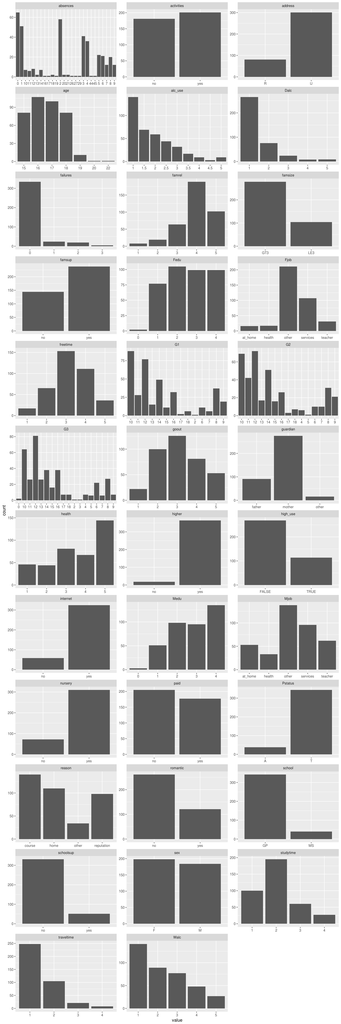

```r
gather(alc) %>% ggplot(aes(value)) + facet_wrap("key", ncol = 3, scales = "free") + geom_bar()
```

Hypothesis based on the data below: Being a male increases the risk to adopt high alcohol consumption habits.

```r
alc %>% group_by(high_use, sex) %>% summarise(count = n(), mean_grade = mean(G3))
```

```
## Source: local data frame [4 x 4]
## Groups: high_use [?]
##
##   high_use    sex count mean_grade
##      <lgl> <fctr> <int>      <dbl>
## 1    FALSE      F   156   11.39744
## 2    FALSE      M   112   12.20536
## 3     TRUE      F    42   11.71429
## 4     TRUE      M    72   10.27778
```

Hypothesis based on the data below: Living in urban area decreases alcohol consumption.

```r
alc %>% group_by(high_use, address) %>% summarise(count = n(), mean_grade = mean(G3))
```

```
## Source: local data frame [4 x 4]
## Groups: high_use [?]
##
##   high_use address count mean_grade
##      <lgl>  <fctr> <int>      <dbl>
## 1    FALSE       R    50   10.40000
## 2    FALSE       U   218   12.04128
## 3     TRUE       R    31   10.74194
## 4     TRUE       U    83   10.83133
```

Hypothesis based on the data below: Getting educational support from family decreases alcohol consumption.

```r
alc %>% group_by(high_use, famsup) %>% summarise(count = n(), mean_grade = mean(G3))
```

```
## Source: local data frame [4 x 4]
## Groups: high_use [?]
##
##   high_use famsup count mean_grade
##      <lgl> <fctr> <int>      <dbl>
## 1    FALSE     no    98   11.85714
## 2    FALSE    yes   170   11.66471
## 3     TRUE     no    46   10.47826
## 4     TRUE    yes    68   11.02941
```

```r
alc %>% group_by(high_use, paid) %>% summarise(count = n(), mean_grade = mean(G3))
```

```
## Source: local data frame [4 x 4]
## Groups: high_use [?]
##
##   high_use   paid count mean_grade
##      <lgl> <fctr> <int>      <dbl>
## 1    FALSE     no   148   11.26351
## 2    FALSE    yes   120   12.31667
## 3     TRUE     no    57   10.66667
## 4     TRUE    yes    57   10.94737
```

**To be continued…**